# HiFi Full-length 16S Analysis Report

## Summary QC statistics

- Samples number: 1
- Final samples number post-DADA2: 1
- Missing samples (Not enough reads, do not pass QC, etc):
- Total number of CCS reads before filtering and primers trimming: 77453
- Was primers trimmed prior to DADA2? Yes
- Note that if downsampling was enabled, the reads will be filtered first, then restricted to a maximum of N reads.
- Total number of reads after quality filtering: 77453 (100%)
- Total number of reads after primers trimming (DADA2 input): 76710 (99.04%)
- Total number of ASVs found: 29
- Average number of ASVs per sample: 29
- Total number of reads in 29 ASVs: 76574 (99.82% of all input reads)

### Classification using VSEARCH with a single database

- ASVs classified at Species level: 29 (100%)
- ASVs classified at Species level (Excluding metagenome/uncultured entries): 29 (100%)
- Percentage reads belong to ASV classified at Species level (Excluding metagenome/uncultured entries): 100%
- ASVs classified at Genus level: 29 (100%)
- ASVs classified at Genus level (Excluding metagenome/uncultured entries): 29 (100%)
- Percentage reads belong to ASV classified at Genus level (Excluding metagenome/uncultured entries): 100%

### Classification using Naive Bayes classifier with SILVA, GTDB and RefSeq + RDP

- ASVs classified at Species level: 27 (93.1%)
- ASVs classified at Species level (Excluding metagenome/uncultured entries): 27 (93.1%)
- Percentage reads belong to ASV classified at Species level (Excluding metagenome/uncultured entries): 89%
- ASVs classified at Genus level: 29 (100%)
- ASVs classified at Genus level (Excluding metagenome/uncultured entries): 29 (100%)
- Percentage reads belong to ASV classified at Genus level (Excluding metagenome/uncultured entries): 100%

## Overall reads filtering and number of full-length reads

- Full-length reads are defined as reads with both F27 and R1492 primers
- Note that full length counts column will only show if cutadapt was used to trim primers (default).

|  | Sample | Reads before quality filter | Reads after quality filter | Full-length Reads | Full-length Reads Percent |
| --- | --- | --- | --- | --- | --- |
| 1 | Zymo_FL16S | 77453 | 77453 | 76710 | 0.990407085587388 |

## Input reads QC (Before filtering and primers removal)

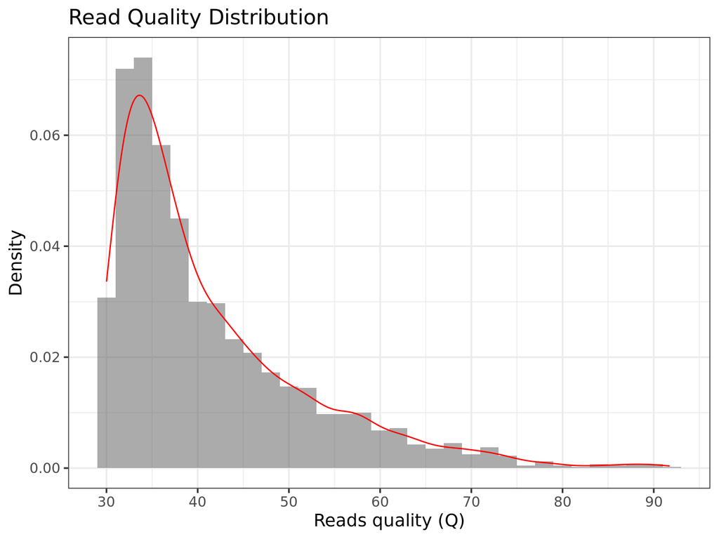

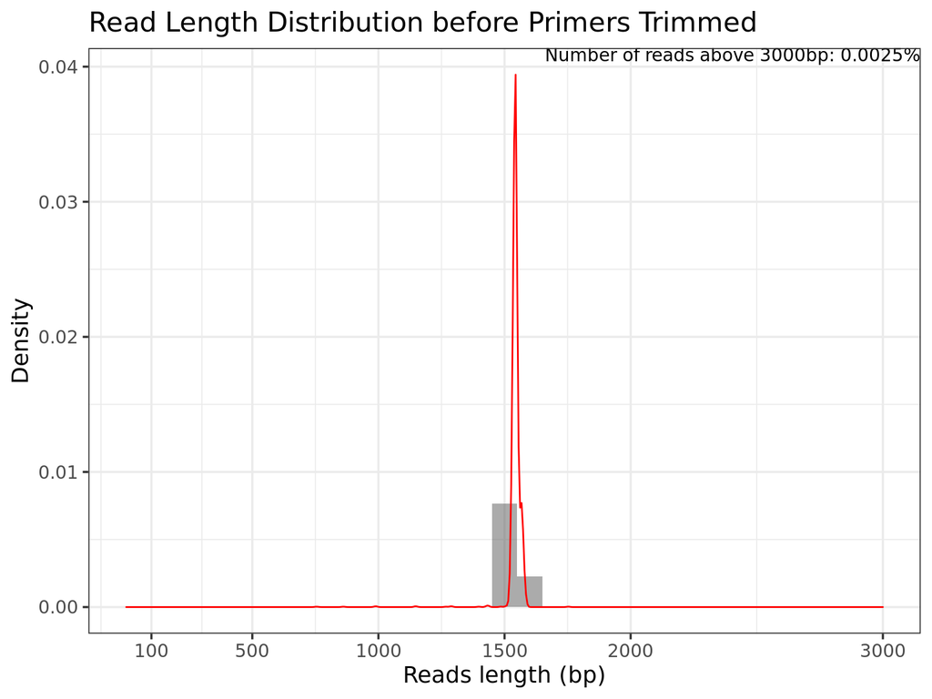

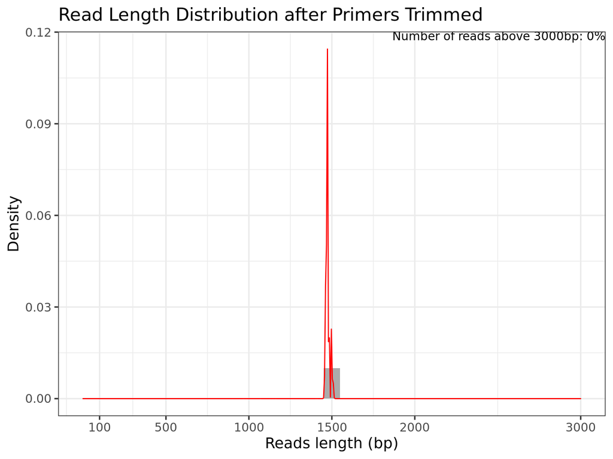

|  | Sample | Median Length (bp) | Median Read Quality | Length 1st Quartile (bp) | Length 3rd Quartile (bp) | Read Quality 1st Quartile (bp) | Read Quality 3rd Quartile (bp) |
| --- | --- | --- | --- | --- | --- | --- | --- |
| 1 | Zymo_FL16S | 1543 | 37.7 | 1539 | 1546 | 33.76 | 45.88 |

## DADA2 QC metrics

|  | sample-id | input | filtered | percentage of input passed filter | denoised | non-chimeric | percentage of input non-chimeric | n_ASV |
| --- | --- | --- | --- | --- | --- | --- | --- | --- |
| 1 | Zymo_FL16S | 76710 | 76690 | 99.97 | 76574 | 76574 | 99.82 | 29 |

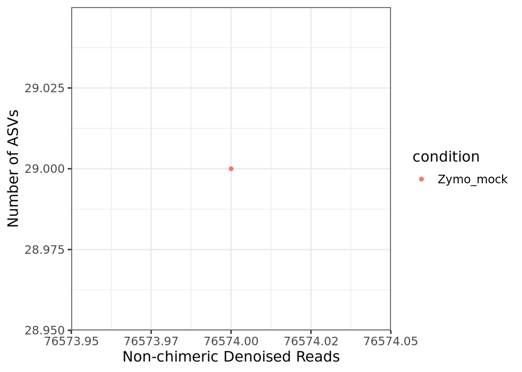

## Top Taxa and Plots

- For interactive view, use the Emperor QZV output from QIIME2 in `results/core-metrics-diversity` folder with QIIME2 View
- Note that if the distances between all samples are zero for a specific method, the plots will not be shown.
- MDS plots use ASVs as input.
- Samples might be missing due to choice of rarefecation depth. Rerun pipeline with `-resume --rarefaction_depth X` to choose a custom rarefaction depth X.

### Bray-Curtis MDS plot

```
## [1] "Bray-Curtis matrix is empty (Did you process only one sample?)"
```

### Weighted and Unweighted Unifrac MDS plot

```
## [1] "Weighted unifrac matrix is empty (Did you process only one sample?)"
```

```
## [1] "Unweighted unifrac matrix is empty (Did you process only one sample?)"
```

### Top 50 ASVs (VSEARCH classification)

|  | OTU | Kingdom | Phylum | Class | Order | Family | Genus | Species | Zymo_FL16S |
| --- | --- | --- | --- | --- | --- | --- | --- | --- | --- |
| 1 | 7149c9557908919f8c8890592dce06c8 | Bacteria | Proteobacteria | Gammaproteobacteria | Enterobacterales | Enterobacteriaceae | Salmonella | Salmonella enterica | 7842 |
| 2 | 6395873ddbb7d1a8e8dfe8652e482e70 | Bacteria | Firmicutes | Bacilli | Bacillales | Bacillaceae | Bacillus | Bacillus spizizenii | 6878 |
| 3 | 27be187284317979c93fd2218ee3722e | Bacteria | Firmicutes | Bacilli | Staphylococcales | Staphylococcaceae | Staphylococcus | Staphylococcus aureus | 6074 |
| 4 | cbb8c7fab987004cb4135dca67812c6e | Bacteria | Firmicutes | Bacilli | Lactobacillales | Listeriaceae | Listeria | Listeria monocytogenes | 6026 |
| 5 | 26cfdb2bcbd3a64a84e9b237d94a97eb | Bacteria | Firmicutes | Bacilli | Lactobacillales | Enterococcaceae | Enterococcus | Enterococcus faecalis | 4143 |
| 6 | 752a3f85a4e352db4139ef9df88b9100 | Bacteria | Firmicutes | Bacilli | Lactobacillales | Listeriaceae | Listeria | Listeria monocytogenes B | 3848 |
| 7 | 579aeb62d4fe9045ccbc28e8a6b199ae | Bacteria | Firmicutes | Bacilli | Bacillales | Bacillaceae | Bacillus | Bacillus spizizenii | 3234 |
| 8 | a0ec2668157ffb2374ece8cad58ecc5f | Bacteria | Proteobacteria | Gammaproteobacteria | Pseudomonadales | Pseudomonadaceae | Pseudomonas | Pseudomonas aeruginosa | 2910 |
| 9 | fde92bfe2bb79cacb52eeaf9b8beb5a7 | Bacteria | Proteobacteria | Gammaproteobacteria | Enterobacterales | Enterobacteriaceae | Escherichia | Escherichia coli | 2530 |
| 10 | a2b7b1f77d2170b8db31477e89a53336 | Bacteria | Firmicutes | Bacilli | Lactobacillales | Enterococcaceae | Enterococcus | Enterococcus faecalis | 2308 |

[output cut: 19 more lines]

### Top 10 Classified Genus (Collapsed to species) with VSEARCH

- Relative abundance is calculated by dividing the number of reads for each ASV to the total number of reads in each sample.
- Heatmap contains only species with >1% abundance in at least 2 samples for the top 10 genus.

|  | Genus | Mean supporting reads across samples | Mean relative abundance across samples |
| --- | --- | --- | --- |
| 1 | Bacillus | 16414 | 0.21 |
| 2 | Staphylococcus | 12418 | 0.16 |
| 3 | Listeria | 11712 | 0.15 |
| 4 | Limosilactobacillus | 9411 | 0.12 |
| 5 | Salmonella | 9124 | 0.12 |
| 6 | Enterococcus | 8693 | 0.11 |
| 7 | Escherichia | 5892 | 0.08 |
| 8 | Pseudomonas | 2910 | 0.04 |

|  | Genus | Species | Zymo_FL16S |
| --- | --- | --- | --- |
| 1 | Bacillus | Bacillus spizizenii | 16414 |
| 2 | Staphylococcus | Staphylococcus aureus | 12418 |
| 3 | Listeria | Listeria monocytogenes | 6026 |
| 4 | Listeria | Listeria monocytogenes B | 5686 |
| 5 | Limosilactobacillus | Limosilactobacillus fermentum | 9411 |
| 6 | Salmonella | Salmonella enterica | 9124 |
| 7 | Enterococcus | Enterococcus faecalis | 8693 |
| 8 | Escherichia | Escherichia coli | 5892 |
| 9 | Pseudomonas | Pseudomonas aeruginosa | 2910 |

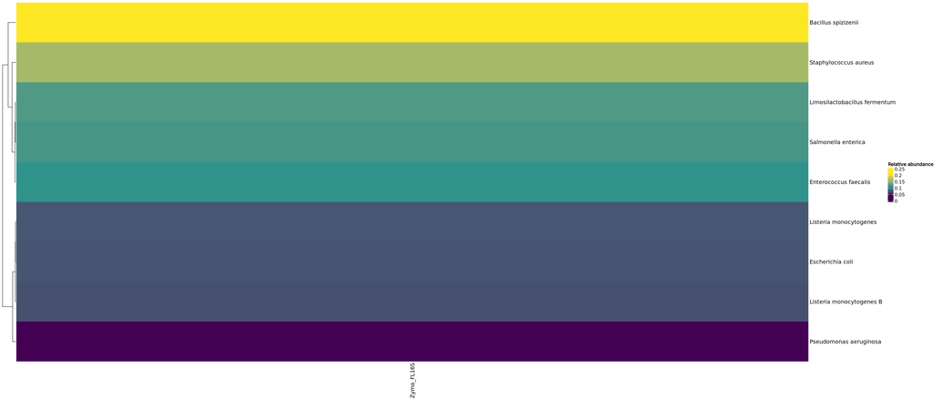

### Top 50 ASVs (Naive Bayes Classifier)

|  | OTU | Kingdom | Phylum | Class | Order | Family | Genus | Species | Zymo_FL16S |
| --- | --- | --- | --- | --- | --- | --- | --- | --- | --- |
| 1 | 7149c9557908919f8c8890592dce06c8 | Bacteria | Proteobacteria | Gammaproteobacteria | Enterobacterales | Enterobacteriaceae | Salmonella | Salmonella enterica | 7842 |
| 2 | 6395873ddbb7d1a8e8dfe8652e482e70 | Bacteria | Firmicutes | Bacilli | Bacillales | Bacillaceae | Bacillus | Unclassified | 6878 |
| 3 | 27be187284317979c93fd2218ee3722e | Bacteria | Firmicutes | Bacilli | Staphylococcales | Staphylococcaceae | Staphylococcus | Staphylococcus aureus | 6074 |
| 4 | cbb8c7fab987004cb4135dca67812c6e | Bacteria | Firmicutes | Bacilli | Lactobacillales | Listeriaceae | Listeria | Listeria monocytogenes B | 6026 |
| 5 | 26cfdb2bcbd3a64a84e9b237d94a97eb | Bacteria | Firmicutes | Bacilli | Lactobacillales | Enterococcaceae | Enterococcus | Enterococcus faecalis | 4143 |
| 6 | 752a3f85a4e352db4139ef9df88b9100 | Bacteria | Firmicutes | Bacilli | Lactobacillales | Listeriaceae | Listeria | Listeria monocytogenes B | 3848 |
| 7 | 579aeb62d4fe9045ccbc28e8a6b199ae | Bacteria | Firmicutes | Bacilli | Bacillales | Bacillaceae | Bacillus | Bacillus intestinalis | 3234 |
| 8 | a0ec2668157ffb2374ece8cad58ecc5f | Bacteria | Proteobacteria | Gammaproteobacteria | Pseudomonadales | Pseudomonadaceae | Pseudomonas | Pseudomonas aeruginosa | 2910 |
| 9 | fde92bfe2bb79cacb52eeaf9b8beb5a7 | Bacteria | Actinobacteriota | Coriobacteriia | Coriobacteriales | Coriobacteriaceae | Collinsella | Collinsella sp900764415 | 2530 |
| 10 | a2b7b1f77d2170b8db31477e89a53336 | Bacteria | Firmicutes | Bacilli | Lactobacillales | Enterococcaceae | Enterococcus | Enterococcus faecalis | 2308 |

[output cut: 19 more lines]

### Top 10 Classified Genus (Collapsed to species) with Naive Bayes Classifier

- Relative abundance is calculated by dividing the number of reads for each ASV to the total number of reads in each sample.
- Heatmap contains only species with >1% abundance in at least 2 samples for the top 10 genus.

|  | Genus | Mean supporting reads across samples | Mean relative abundance across samples |
| --- | --- | --- | --- |
| 1 | Bacillus | 16414 | 0.21 |
| 2 | Staphylococcus | 12418 | 0.16 |
| 3 | Listeria | 11712 | 0.15 |
| 4 | Limosilactobacillus | 9411 | 0.12 |
| 5 | Salmonella | 9124 | 0.12 |
| 6 | Enterococcus | 8693 | 0.11 |
| 7 | Collinsella | 5042 | 0.07 |
| 8 | Pseudomonas | 2910 | 0.04 |
| 9 | Escherichia-Shigella | 850 | 0.01 |

|  | Genus | Species | Zymo_FL16S |
| --- | --- | --- | --- |
| 1 | Bacillus | Bacillus intestinalis | 6355 |
| 2 | Bacillus | Bacillus sp010093085 | 1564 |
| 3 | Bacillus | Unclassified | 8495 |
| 4 | Staphylococcus | Staphylococcus aureus | 12418 |
| 5 | Listeria | Listeria monocytogenes B | 11712 |
| 6 | Limosilactobacillus | Limosilactobacillus fermentum | 9411 |
| 7 | Salmonella | Salmonella enterica | 9124 |
| 8 | Enterococcus | Enterococcus faecalis | 8693 |
| 9 | Collinsella | Collinsella sp900764415 | 5042 |
| 10 | Pseudomonas | Pseudomonas aeruginosa | 2910 |

[output cut: 1 more lines]

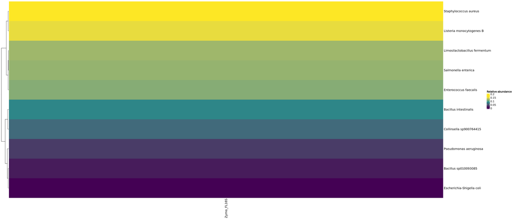